# Chapter 5 – Dimensionality reduction techniques

```
## [1] "Thu Nov 26 19:27:27 2020"
```

**Useful links to PCA**  
http://factominer.free.fr/  
https://setosa.io/ev/principal-component-analysis/  
https://arxiv.org/pdf/1404.1100.pdf  
https://www.fbbva.es/microsite/multivariate-statistics/biplots.html  
https://youtu.be/aiqGyLGrQ48?list=PLnZgp6epRBbTsZEFXi_p6W48HhNyqwxIu

## 5.1 Data wrangling

Comment: Continue data wrangling from last week. Change non-numeric data to numeric data, remove rows with NA-s, keep only country-based data, keep selected variables

```r
library(stringr); library(dplyr); library(tidyr)
```

### 5.1.0 Read the data

```r
human <- read.csv("http://s3.amazonaws.com/assets.datacamp.com/production/course_2218/datasets/human1.txt", stringsAsFactors = F)

str(human)
summary(human)
dim(human)
```

### 5.1.1 Mutate data

Change 12,000-style variable to numeric 12000-style

```r
human = mutate(human, GNI=as.numeric(str_replace(human$GNI, pattern=",", replace ="")))
summary(human$GNI)
```

### 5.1.2 Keep selected variables

```r
# Columns to keep
keep <- c("Country", "Edu2.FM", "Labo.FM", "Edu.Exp", "Life.Exp", "GNI", "Mat.Mor", "Ado.Birth", "Parli.F")

human <- select(human, one_of(keep))
names(human)
dim(human)
```

### 5.1.3 Remove all rows with missing values

```r
human <- filter(human, complete.cases(human))
dim(human)
```

### 5.1.4 Remove all rows with region data

```r
# Last rows on human data
tail(human,n=10)

# Choose everything until the last 7 observations
human <- human[1:(nrow(human) - 7), ]

dim(human)
```

### 5.1.5 Adapt row names from variable country and save the data

```r
rownames(human) <- human$Country
human <- dplyr::select(human, -Country)

dim(human)

write.csv(human, file = (paste0(getwd(), "/data/human.csv")), row.names=T)
```

## 5.2 Data analysis

Read data

```r
human = read.csv(file = (paste0(getwd(), "/data/human.csv")), row.names=1)
```

Data has 155 rows and 8 variables.

Today’s libraries

```r
library(ggplot2); library(GGally)
library(tidyr); library(dplyr)
library(corrplot); library(MASS)
```

### 5.2.1 Overview of data

```r
names(human)
```

```
## [1] "Edu2.FM"   "Labo.FM"   "Edu.Exp"   "Life.Exp"  "GNI"       "Mat.Mor"
## [7] "Ado.Birth" "Parli.F"
```

Explabnation of variables in dataset:

| variables | explanation |
| --- | --- |
| Edu.Exp | Expected years of schooling |
| Life.Exp | Life expectancy at birth |
| GNI | Gross National Income per capita |
| Mat.Mor | Maternal mortality ratio |
| Ado.Birth | Adolescent birth rate |
| Parli.F | Percetange of female representatives in parliament |
| Edu2.FM | Ratio of proportion of females and males with at least secondary education (educational inequality between females and males) |
| Labo.FM | Ratio of proportion of females and males in the labour force (labour force inequality between females and males) |

```r
str(human)
```

```
## 'data.frame':    155 obs. of  8 variables:
##  $ Edu2.FM  : num  1.007 0.997 0.983 0.989 0.969 ...
##  $ Labo.FM  : num  0.891 0.819 0.825 0.884 0.829 ...
##  $ Edu.Exp  : num  17.5 20.2 15.8 18.7 17.9 16.5 18.6 16.5 15.9 19.2 ...
##  $ Life.Exp : num  81.6 82.4 83 80.2 81.6 80.9 80.9 79.1 82 81.8 ...
##  $ GNI      : int  64992 42261 56431 44025 45435 43919 39568 52947 42155 32689 ...
##  $ Mat.Mor  : int  4 6 6 5 6 7 9 28 11 8 ...
##  $ Ado.Birth: num  7.8 12.1 1.9 5.1 6.2 3.8 8.2 31 14.5 25.3 ...
##  $ Parli.F  : num  39.6 30.5 28.5 38 36.9 36.9 19.9 19.4 28.2 31.4 ...
```

```r
summary(human)
```

```
##     Edu2.FM          Labo.FM          Edu.Exp         Life.Exp
##  Min.   :0.1717   Min.   :0.1857   Min.   : 5.40   Min.   :49.00
##  1st Qu.:0.7264   1st Qu.:0.5984   1st Qu.:11.25   1st Qu.:66.30
##  Median :0.9375   Median :0.7535   Median :13.50   Median :74.20
##  Mean   :0.8529   Mean   :0.7074   Mean   :13.18   Mean   :71.65
##  3rd Qu.:0.9968   3rd Qu.:0.8535   3rd Qu.:15.20   3rd Qu.:77.25
##  Max.   :1.4967   Max.   :1.0380   Max.   :20.20   Max.   :83.50
##       GNI            Mat.Mor         Ado.Birth         Parli.F
##  Min.   :   581   Min.   :   1.0   Min.   :  0.60   Min.   : 0.00
##  1st Qu.:  4198   1st Qu.:  11.5   1st Qu.: 12.65   1st Qu.:12.40
##  Median : 12040   Median :  49.0   Median : 33.60   Median :19.30
##  Mean   : 17628   Mean   : 149.1   Mean   : 47.16   Mean   :20.91
##  3rd Qu.: 24512   3rd Qu.: 190.0   3rd Qu.: 71.95   3rd Qu.:27.95
##  Max.   :123124   Max.   :1100.0   Max.   :204.80   Max.   :57.50
```

All variables are numeric. Values are on different scale, and results probably depends on history and development of county (poorer countries have lower life expectancy, less educated females, higher maternal mortality etc).

Visualize the human variables:

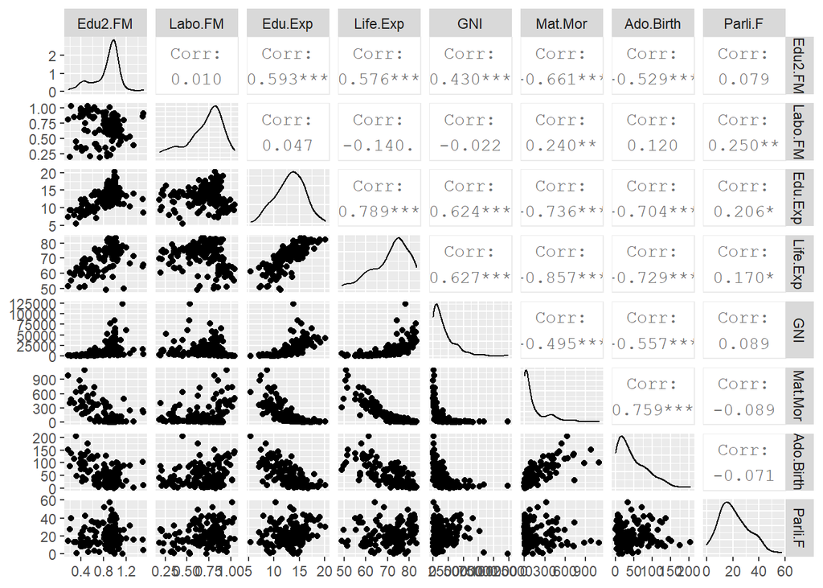

```r
ggpairs(human)
```

Variables are not distributed normally.

High positive correlations (r>0.7) are between:

- life expectancy and expected years of schooling
- maternal mortality ratio and adolescent birth rate

High negative correlatios (r<-0.7) are between:

- maternal mortality ratio and expected years of schooling
- maternal mortality ratio and life expectancy
- life expectancy and adolescent birth rate

### 5.2.2 PCA, not standardized data

*A biplot is a way of visualizing the connections between two representations of the same data.* *First, a simple scatter plot is drawn where the observations are represented by two principal components (PC’s). Then, arrows are drawn to visualize the connections between the original variables and the PC’s. The following connections hold: * The angle between the arrows can be interpret as the correlation between the variables. * The angle between a variable and a PC axis can be interpret as the correlation between the two. * The length of the arrows are proportional to the standard deviations of the variables*

```r
pca_human <- prcomp(human)
summary(pca_human)
```

```
## Importance of components:
##                              PC1      PC2   PC3   PC4   PC5   PC6    PC7    PC8
## Standard deviation     1.854e+04 185.5219 25.19 11.45 3.766 1.566 0.1912 0.1591
## Proportion of Variance 9.999e-01   0.0001  0.00  0.00 0.000 0.000 0.0000 0.0000
## Cumulative Proportion  9.999e-01   1.0000  1.00  1.00 1.000 1.000 1.0000 1.0000
```

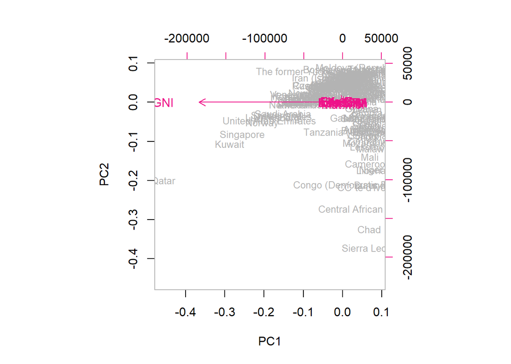

```r
biplot(pca_human, choices = 1:2, cex=c(0.8, 1),col = c("grey70", "deeppink2"))
```

### 5.2.3 PCA, standardized data

```r
human_std <- scale(human)
pca_human_std <- prcomp(human_std)
summary(pca_human_std)
```

```
## Importance of components:
##                           PC1    PC2     PC3     PC4     PC5     PC6     PC7
## Standard deviation     2.0708 1.1397 0.87505 0.77886 0.66196 0.53631 0.45900
## Proportion of Variance 0.5361 0.1624 0.09571 0.07583 0.05477 0.03595 0.02634
## Cumulative Proportion  0.5361 0.6984 0.79413 0.86996 0.92473 0.96069 0.98702
##                            PC8
## Standard deviation     0.32224
## Proportion of Variance 0.01298
## Cumulative Proportion  1.00000
```

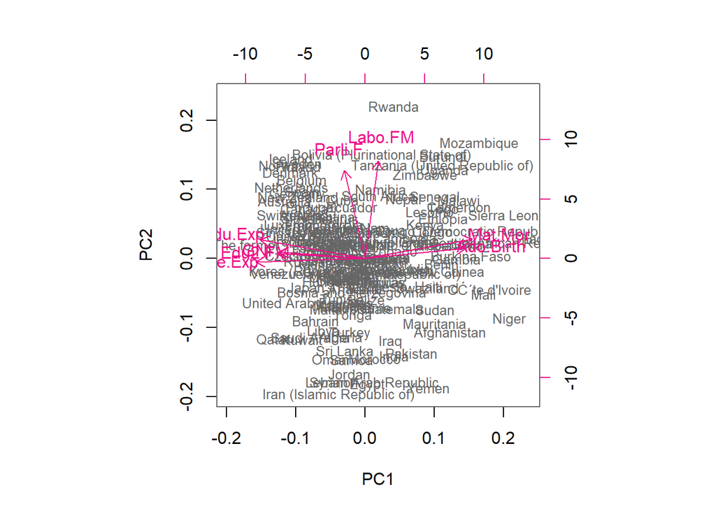

```r
biplot(pca_human_std, choices = 1:2, cex=c(0.8, 1),col = c("grey40", "deeppink2"))
```

On the first PCA analysis is key-variable Gross National Income per capita (GNI). As it has high values (on really different scale compared others) and huge variability, it holds 99% of data variability and principal component 1 is highly tilted to GNI.

The second PCA analysis is done on scaled data (means are around zero and standard deviation should be 1). First PC holds 53% of variability, second 16% and third 9%. It seems that preferred number of principal components is two.

By the plot:

- percetange of female representatives in parliament (Parli.F) and labour force inequality between females and males (Labo.FM) is going to same PC (PC2). Arrows are on the same direction and angle between them is small, it means they positively correlated.
- maternal mortality ratio (Mat.Mor) is related with adolescent birth rate (Ado.Birth) and it belongs to the first principal component
- Arrows to expected years of schooling (Edu2.FM), Life expectancy at birth (Life.Exp), Gross National Income per capita)(GNI), educational inequality between females and males (Edu2.FM) are near to each other and belongs to PC1 (as birth rate and mortality ratio) but on other direction.

### 5.2.4 Interpretation

Results are reasonable.

Percetange of female representatives in parliament (Parli.F) and labour force inequality between females and males (Labo.FM) are related and both show female rights on the country - in the country, where females doesn’t go to payed work, they can’t go to politics ether.

Maternal mortality ratio (Mat.Mor) and is related with adolescent birth rate (Ado.Birth) and they both represent women’s heath care. Higher scores means poorer health care.

The last group is little more tricky. High life expectancy at birth shows high healt care and well-being of society. Greater expected years of schooling shows greater wealth and development of country. Higher Gross National Income per capita shows higher wealth and development of country. Higher educational inequality between females and males shows poorer development of country and also lower women’s health care. They are in coherent, but for my opinion they measure little different sides of society.